# CareerVillage.org

references - https://towardsdatascience.com/learning-to-rank-with-python-scikit-learn-327a5cfd81f

```python
# import statements for all of the packages
import pandas as pd
import numpy as np
import matplotlib.pyplot as plt
%matplotlib inline
```

## Data exploration

As per out solution we will need 3 csv files from the dataset which gives the information about the professionals, details of the questions asked and details of the asnwers given to those questions.

```python
# Loading professional data and printing a few lines
df_professionals = pd.read_csv('dataset/professionals.csv')
df_professionals.head()
```

|  | professionals_id | professionals_location | professionals_industry | professionals_headline | professionals_date_joined |
| --- | --- | --- | --- | --- | --- |
| 0 | 9ced4ce7519049c0944147afb75a8ce3 | NaN | NaN | NaN | 2011-10-05 20:35:19 UTC+0000 |
| 1 | f718dcf6d2ec4cb0a52a9db59d7f9e67 | NaN | NaN | NaN | 2011-10-05 20:49:21 UTC+0000 |
| 2 | 0c673e046d824ec0ad0ebe012a0673e4 | New York, New York | NaN | NaN | 2011-10-18 17:31:26 UTC+0000 |
| 3 | 977428d851b24183b223be0eb8619a8c | Boston, Massachusetts | NaN | NaN | 2011-11-09 20:39:29 UTC+0000 |
| 4 | e2d57e5041a44f489288397c9904c2b2 | NaN | NaN | NaN | 2011-12-10 22:14:44 UTC+0000 |

```python
df_professionals['professionals_industry'].fillna('not available', inplace=True)
```

```python
# Loading questions data and printing a few lines
df_questions = pd.read_csv('dataset/questions.csv')
df_questions.head()
```

|  | questions_id | questions_author_id | questions_date_added | questions_title | questions_body |
| --- | --- | --- | --- | --- | --- |
| 0 | 332a511f1569444485cf7a7a556a5e54 | 8f6f374ffd834d258ab69d376dd998f5 | 2016-04-26 11:14:26 UTC+0000 | Teacher career question | What is a maths teacher? what is a ma... |
| 1 | eb80205482e4424cad8f16bc25aa2d9c | acccbda28edd4362ab03fb8b6fd2d67b | 2016-05-20 16:48:25 UTC+0000 | I want to become an army officer. What can I d... | I am Priyanka from Bangalore . Now am in 10th ... |
| 2 | 4ec31632938a40b98909416bdd0decff | f2c179a563024ccc927399ce529094b5 | 2017-02-08 19:13:38 UTC+0000 | Will going abroad for your first job increase ... | I'm planning on going abroad for my first job.... |
| 3 | 2f6a9a99d9b24e5baa50d40d0ba50a75 | 2c30ffba444e40eabb4583b55233a5a4 | 2017-09-01 14:05:32 UTC+0000 | To become a specialist in business management... | i hear business management is a hard way to ge... |
| 4 | 5af8880460c141dbb02971a1a8369529 | aa9eb1a2ab184ebbb00dc01ab663428a | 2017-09-01 02:36:54 UTC+0000 | Are there any scholarships out there for stude... | I'm trying to find scholarships for first year... |

```python
# Loading answers data and printing a few lines
df_answers = pd.read_csv('dataset/answers.csv')
df_answers.head()
```

|  | answers_id | answers_author_id | answers_question_id | answers_date_added | answers_body |
| --- | --- | --- | --- | --- | --- |
| 0 | 4e5f01128cae4f6d8fd697cec5dca60c | 36ff3b3666df400f956f8335cf53e09e | 332a511f1569444485cf7a7a556a5e54 | 2016-04-29 19:40:14 UTC+0000 | <p>Hi!</p>\n<p>You are asking a very interesti... |
| 1 | ada720538c014e9b8a6dceed09385ee3 | 2aa47af241bf42a4b874c453f0381bd4 | eb80205482e4424cad8f16bc25aa2d9c | 2018-05-01 14:19:08 UTC+0000 | <p>Hi. I joined the Army after I attended coll... |
| 2 | eaa66ef919bc408ab5296237440e323f | cbd8f30613a849bf918aed5c010340be | eb80205482e4424cad8f16bc25aa2d9c | 2018-05-02 02:41:02 UTC+0000 | <p>Dear Priyanka,</p><p>Greetings! I have answ... |
| 3 | 1a6b3749d391486c9e371fbd1e605014 | 7e72a630c303442ba92ff00e8ea451df | 4ec31632938a40b98909416bdd0decff | 2017-05-10 19:00:47 UTC+0000 | <p>I work for a global company who values high... |
| 4 | 5229c514000446d582050f89ebd4e184 | 17802d94699140b0a0d2995f30c034c6 | 2f6a9a99d9b24e5baa50d40d0ba50a75 | 2017-10-13 22:07:33 UTC+0000 | I agree with Denise. Every single job I've had... |

```python
# Loading comments data and printing a few lines
df_comments = pd.read_csv('dataset/comments.csv')
df_comments.head()
```

|  | comments_id | comments_author_id | comments_parent_content_id | comments_date_added | comments_body |
| --- | --- | --- | --- | --- | --- |
| 0 | f30250d3c2ca489db1afa9b95d481e08 | 9fc88a7c3323466dbb35798264c7d497 | b476f9c6d9cd4c50a7bacdd90edd015a | 2019-01-31 23:39:40 UTC+0000 | First, you speak to recruiters. They are train... |
| 1 | ca9bfc4ba9464ea383a8b080301ad72c | de2415064b9b445c8717425ed70fd99a | ef4b6ae24d1f4c3b977731e8189c7fd7 | 2019-01-31 20:30:47 UTC+0000 | Most large universities offer study abroad pro... |
| 2 | c354f6e33956499aa8b03798a60e9386 | 6ed20605002a42b0b8e3d6ac97c50c7f | ca7a9d7a95df471c816db82ee758f57d | 2019-01-31 18:44:04 UTC+0000 | First, I want to put you at ease that the oppo... |
| 3 | 73a6223948714c5da6231937157e4cb7 | d02f6d9faac24997a7003a59e5f34bd3 | c7a88aa76f5f49b0830bfeb46ba17e4d | 2019-01-31 17:53:28 UTC+0000 | Your question submission was great! I just wan... |
| 4 | 55a89a9061d44dd19569c45f90a22779 | e78f75c543e84e1c94da1801d8560f65 | c7a88aa76f5f49b0830bfeb46ba17e4d | 2019-01-31 14:51:53 UTC+0000 | Thank you. I'm new to this site. I'm sorry if ... |

```python
# Loading tags data and printing a few lines
df_tags = pd.read_csv('dataset/tag_questions.csv')
df_tags.head()
```

|  | tag_questions_tag_id | tag_questions_question_id |
| --- | --- | --- |
| 0 | 28930 | cb43ebee01364c68ac61d347a393ae39 |
| 1 | 28930 | 47f55e85ce944242a5a347ab85a8ffb4 |
| 2 | 28930 | ccc30a033a0f4dfdb2eb987012f25792 |
| 3 | 28930 | e30b274e48d741f7bf50eb5e7171a3c0 |
| 4 | 28930 | 3d22742052df4989b311b4195cbb0f1a |

```
Text(0.5,1,'Count of Available Datasets')
```

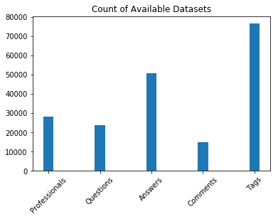

```python
# fig, ax = plt.subplots()
# ax.bar =
plt.bar(['Professionals', 'Questions', 'Answers', 'Comments', 'Tags'],
        [len(df_professionals), len(df_questions), len(df_answers), len(df_comments), len(df_tags)], width = 0.2)
plt.xticks(rotation=45)
plt.title("Count of Available Datasets")
```

## Processing the industry column of the professional data

```python
# convert all the values in the industry columns to lower case
df_professionals['professionals_industry'] = df_professionals['professionals_industry'].str.lower()
```

```python
# get the unique industries
unique_industries = pd.Series(df_professionals['professionals_industry'].unique().astype(str))
unique_industries
```

```
0                                           not available
1                                          special events
2                                  education, tech, media
3                                        renewable energy
4                                hospitality & consulting
5                                             engineering
6                                                software
7                                                  mobile
8               healthcare, pharmaceuticals, life science
9                                                      ip
10           business development, electrical engineering
11                               environmental consulting
12                                           software/web
13                         biotechnology / pharmaceutical
14                                           tech / legal
```

[output cut: 47 more lines]

```python
# there is still redundancy in the column values such as these
unique_industries[unique_industries.str.contains('computer')==True]
```

```
24                                      computer software
67                                         computer games
103                    computer science, machine learning
114                                     computer hardware
120                           computer & network security
143                                   computer networking
213                  computer software (formerly biology)
226                                      computer science
285                                     computer_software
330                computer software/media/communications
373                         video games/computer software
430                                 computer : all fields
435     video games, architectural visualization, comp...
472                      computer networking/ video games
499                                  computer engineering
```

[output cut: 47 more lines]

all these 74 entries correspond to a single field of computers.

```python
# merge such entries to form a single common industry

industries = unique_industries.copy()

''' Function to merge the redundant industries '''
def merge_duplicates(industry):
    count = 0
    for i in industries:
        if industry in i:
            count = count + 1
        if count == 2:
            industries.drop(industries[industries == i].index, inplace=True)
            count = 1
```

```python
# call merge duplicate function on the full column of industry
unique_industries.apply(merge_duplicates)
industries
```

```
0                                           not available
1                                          special events
2                                  education, tech, media
3                                        renewable energy
4                                hospitality & consulting
5                                             engineering
6                                                software
7                                                  mobile
8               healthcare, pharmaceuticals, life science
9                                                      ip
15                                                finance
18                                                nursing
19                                               internet
20                                                 design
22                       professional training & coaching
```

[output cut: 47 more lines]

```python
# create a temporary copy of industry column
temp_prof_industry = df_professionals['professionals_industry'].astype(str).copy()
```

```python
''' Function to update the industries according to the new unique industries found '''
def update_industries(industry):
    global temp_prof_industry
    def check_industry(i):
        if industry in i:
            return industry
        else:
            return i
    temp_prof_industry = temp_prof_industry.apply(check_industry)
```

```python
# update the industries for all records
for industry in temp_prof_industry:
    update_industries(industry)
```

```python
industry_prof = list()

''' Function to group professionals according to their industries '''
def industry_prof_map(industry):
    global industry_prof
    industry_prof.append(list(df_professionals[df_professionals['professionals_industry'].str.contains(industry)==True]['professionals_id']))
```

```python
# group professionals according to their industries
industries.apply(industry_prof_map)
```

```
0       None
1       None
2       None
3       None
4       None
5       None
6       None
7       None
8       None
9       None
15      None
18      None
19      None
20      None
22      None
```

[output cut: 47 more lines]

```python
# creating a table with industry and a list of professionals under that industry
df_industry_prof_map = pd.DataFrame(list(zip(industries, industry_prof)), columns=['industry', 'prof_ids'])
df_industry_prof_map
```

|  | industry | prof_ids |
| --- | --- | --- |
| 0 | not available | [9ced4ce7519049c0944147afb75a8ce3, f718dcf6d2e... |
| 1 | special events | [68ecc66323b8418092fdd724aaf5be94] |
| 2 | education, tech, media | [c79d4e4fd9af4ab7a7e6b6f433128476] |
| 3 | renewable energy | [5e9ee8611ee34185a90e4c40f02567ff, 70d367f85f4... |
| 4 | hospitality & consulting | [1e4cc96c24344c8b806c26c3e6746167] |
| 5 | engineering | [7a834b10a8c4494c96ca3fce733c7185, bccd61129e1... |
| 6 | software | [1ec14aee9311480681dfa81b0f193de8, 49ae0135ce3... |
| 7 | mobile | [ccad7c94952a49b9ad0fb85b09d1398d, c3668d2d663... |
| 8 | healthcare, pharmaceuticals, life science | [44b2484ecd3642c6a47514f3876cf14a] |
| 9 | ip | [36adb6e6f7934f3c82eac29a615d066f, 54712234948... |
| 10 | finance | [c1bda2764ee642b3859b1ca6839fa16c, a2af59f297e... |
| 11 | nursing | [ff9b24dcebc744bebc50f2472502efb9, 97b06576926... |
| 12 | internet | [e1cc34cbbca547bf9b68190944445f2c, fbe22e7dc01... |
| 13 | design | [a854be38c843411d9eb53f97d161b72e, a28595f674b... |
| 14 | professional training & coaching | [1920df1bf7e648e29f7533b298980523, 5aa9f41cb95... |
| 15 | marketing and advertising | [9733735b1bff4af08dd81468e07e310d, 187be289f23... |
| 16 | financial services | [16ab1a87349a47ceabf559df71f4cf4d, 124c57a14fc... |
| 17 | consumer goods | [ce690b8282214dff94dc683a9d94f914, fb6b251b270... |
| 18 | investment banking | [141d430fd7b74bb7aed08a4d2edeeb63, 12b99c9fbc0... |
| 19 | publishing | [54feaae2d491431590d38c4e03909a62, 494683ac7d8... |
| 20 | research | [67832cd603d14d0c9c98a4b0e9ed0d4f, 3571c074def... |
| 21 | public relations and communications | [bf41121e643b484a96c1d61eb7b16aaf, 36bfabf3b85... |
| 22 | insurance | [14f4a82763224f509b1ceacc57437f32, e5afebc1137... |
| 23 | accounting | [bc531d228e874797a5d22f3b2fbd8387, 5cbd4a64a32... |
| 24 | judiciary | [b0975dbf9559455eb28ab537bb9ae03d, 03b2e5a5a41... |
| 25 | civic & social organization | [a5806385db1845cc996f66a99cc19dab, 4e2f32586d9... |
| 26 | 3d printing & ecommerce | [3330f8a7835346a2a91f9393ae21efee] |
| 27 | new ventures | [acf136de48684cf8aca049a78a28cfe6] |
| 28 | renewables & environment | [8eaf5c43f2f84c1180f45ba424d6f8e6, 4f1510067a5... |
| 29 | airlines/aviation | [fd17b2c99949412999f878ca3e777c98, f902b2c1390... |
| ... | ... | ... |
| 322 | ingeniería biomédica | [70fd0781b2d448728ea618d0e06d92a5] |
| 323 | not applicable | [b0b886fe230e4a6da5a8f402195f50b5] |
| 324 | illustration | [349db306672e425f9481e6c30d84afe5, 63e80021bee... |
| 325 | dental hygiene and preventive oral care specia... | [cd92dd139f364ee8b5366c0ffe420e39] |
| 326 | socialworker | [9255f11743df47f3a13a2d51ba2bdc6f] |
| 327 | utd | [06ef492a2e744b7d8c47350091590079] |
| 328 | entertaiment | [b4d5d778734c45f9bc38a1f5a71ffdbd, 093f1cce57a... |
| 329 | cannabis | [5245dc8d42884cec93a08eade57bad1c] |
| 330 | metal products | [5384b90ac265436da630759217befb9a] |
| 331 | govt | [e68e18337e08483d80c89d2f4ea23020] |
| 332 | acting | [b08d5a713916472a9050e15580ff4bf1, 3846e3ac730... |
| 333 | esl | [b805d14965b54e48902f1c5f7dc1a536, d232f8abd5c... |
| 334 | mathematics | [1f1595f70b664864a04fea1487257ecb, 709f524bc2f... |
| 335 | training and development | [bdb541ecf48e440f91ccffb11529c663, f7d7fe72b7b... |
| 336 | aerosapce | [c0ba55937a3242d79d5b3b4f4e70d7ab] |
| 337 | propulsion systems | [c5feded21f6a4ee2abb256bfaae1877c] |
| 338 | arco gas station | [b77eae0fb94d44b59082659da8541089] |
| 339 | theater | [8ffae02d90fc44b583dc0a51956c66e1, 71fefa1523a... |
| 340 | www.linkedin.com/in/jyotsna-penumaka | [435f53c586fd42e4ae95fb202bfa99bd] |
| 341 | children | [dc6b4529d88140c7aadceed95fb04266, 2bb3e0f68cb... |
| 342 | all industries | [769d7095b49c468aa445dc24935ec9c8, ceb4c77d26c... |
| 343 | receptionist | [9bb08b9af02c4fb48fd4b44dd13a395e] |
| 344 | dont know | [ac557e68af274f49b4403b42822b5027] |
| 345 | masters degree | [5e21607bd84c43d5b151633d0bb2edcf] |
| 346 | commuications | [09e235ad46294e1c9b02b650921cec43] |
| 347 | sanidad vegetal | [da25fe81a092463f8d833c36d200d769] |
| 348 | police | [97b502378c54444bbb0e0c1a6cfca62f, 6708800d6d0... |
| 349 | cloud networking | [cb71f978be1948cfa68408ba1d0660cb] |
| 350 | care giver | [432e57ce3aee442a8cb949203a66a5f3] |
| 351 | dev sec ops | [95744d70d19542e78573da8fb3ece5b1] |

352 rows × 2 columns

```python
df_industry_prof_map['prof_ids'].ravel()
```

```
array([list(['9ced4ce7519049c0944147afb75a8ce3', 'f718dcf6d2ec4cb0a52a9db59d7f9e67', '0c673e046d824ec0ad0ebe012a0673e4', '977428d851b24183b223be0eb8619a8c', 'e2d57e5041a44f489288397c9904c2b2', 'c9bfa93898594cbbace436deca644c64', 'ed85488fb5e941eaa97014137fcbf317', '102fb92c28034ad988b593d0111cb4bb',…
       list(['68ecc66323b8418092fdd724aaf5be94']),
       list(['c79d4e4fd9af4ab7a7e6b6f433128476']),
       list(['5e9ee8611ee34185a90e4c40f02567ff', '70d367f85f4044998b7579473be442d9', '0a920bbc06f74dc48fa7f3e0a104b3c3']),
       list(['1e4cc96c24344c8b806c26c3e6746167']),
       list(['7a834b10a8c4494c96ca3fce733c7185', 'bccd61129e1c495e94b28e8e6d326388', 'b341636a39204cb5869279b69b2641ca', '34f66d8e7e65463ea8e8ad7f85f502f4', '79f9b7483def42cdb9b302a91138ceb2', '955e264400f341c793240b34cdd14101', '82bfa5043b6a47fa869d6777b08e13fa', '23b6df4d73fb4d9bab3eafb6dd8bfb86',…
       list(['1ec14aee9311480681dfa81b0f193de8', '49ae0135ce3548ffab2eb79b9c1f2882', 'e327399c48584fcf81e433828a6d8715', '92494d9dc2124507972c5306badc6727', 'c27ee09eaf6c4716ba89b8467a36fcca', '207c8c62bcaa4033885a24a8a5a10d51', '46f00e77fe1347ac85af5ae0e8a5aef4', '34df5c19a4044e9791978f8ed867a350',…
       list(['ccad7c94952a49b9ad0fb85b09d1398d', 'c3668d2d66334063bbeaf07cdb273ad9', 'f4ada8c04126447382abea3a72021e23', 'fad38fee155340d78efba1d793220e92', 'e02ee61606c44a1fa2783baabb18233b', 'a23a34c2908b4a899412df1c9e759f7a', '36a6aa1b64044f6e8d73c38e7ed843b0', '6d501e5a1a6b41bc92fca2df6464f32b',…
       list(['44b2484ecd3642c6a47514f3876cf14a']),
       list(['36adb6e6f7934f3c82eac29a615d066f', '547122349484428c885dd9d18051b71e', '04eef7fd6f4e4ec7a36f3341b1aef72e', '4d0793926fe345aa958d1796c9adf5fa', '9c0dc9e7ba084657883f0c0a00b61b82', 'b8b77df14ad94e7bb64f14eeffb72d9b', '0826bc169092451d850bcbe9759b93a3', '7556a9e965ae4015ad917d0b1dde2423',…
       list(['c1bda2764ee642b3859b1ca6839fa16c', 'a2af59f297e240da8119dcbaf804db2e', '87f49d6521904c7d9cf0736804bd2536', 'bcd803f71e804d878dc1fe65fa3214ef', '58e5744b179c412ea34d1f90ad5cfb81', '65734da6aea4494088deb16a5eda44d6', 'a89b554364f4471a8efb46da88ac78d8', '1baec1019cd24bdd956ce6d49cb703f4',…
       list(['ff9b24dcebc744bebc50f2472502efb9', '97b06576926641838472728d198cefea', 'fe63fe37d6d842d8a7cb12183987173a', '49dba8c375214760bb7ab8e616a5f91b', '3017ab48ef64404193186b3c8502764d', 'c9b3f8c7bafa4c03997b961615fdb003', '43d85454aef542efb1b6349c26469423', '434f0f0831bc43fdb52e435fd851904e',…
       list(['e1cc34cbbca547bf9b68190944445f2c', 'fbe22e7dc01c4580a3a79b03e7a67474', 'b6a6a5fe48dc4a819ac6fd3c05c0fd79', '9ce1a6a0bb3c4cc49bc6414788b80c49', '42aa72bd930b45a3bcd2608a07778333', '3ee982f64a8042afb993d9944d2a46b0', '3f7d362aac0a4304b31cd37f54f41774', '3610651286574769b899efd7204265f9',…
       list(['a854be38c843411d9eb53f97d161b72e', 'a28595f674b94c469440a044789bc4e7', '85277e26b7834849bc653e940c3658f0', 'b9389146aa5043dcbf5d7b4ce903be9d', '4b7737cb8c46400795bdba3a4f333997', '0bb342f40b9049a783df12cc5e8dc552', 'bc48657c689c48d98d881a305b36aeb0', '89928f2895094a4db72b94e3377e5f10',…
       list(['1920df1bf7e648e29f7533b298980523', '5aa9f41cb958462bb1851aa5d65ccdb4', '24e8fdd2e4694913b2f5965608207dc6', '05586d2e55ac4bc395f99f86731f7b22', '89d883fe7cd74ebbb9b95f53f440a8b9', '5592a9439d5545abac4644e34853f56a', '23f80c2415c3414698ab3bce550aa3d7', '9927ac0afb3142139fb66e9b91825e73',…
       list(['9733735b1bff4af08dd81468e07e310d', '187be289f234468f9f3bc296dfb91011', '37b504f5e71e46c6a7b793b13dedf5ec', '21fde7c178284240b12fed9e94b9a52c', '497f99e9e1b34e9bafedb56abefffb44', '949bc8e496c140d9b9f4000c979c5195', 'fed1bc4cf76645e1a497372c11b0ee38', '8e94dc977c4f4ac6b50b7146e3d1bb5e',…
       list(['16ab1a87349a47ceabf559df71f4cf4d', '124c57a14fc7408bbd7c2c79fd574c83', 'eb8ab86e3aeb4596a93c824ff6684128', '5d8077c786bb45b09944b0aa8b7f4cd0', '6d3aeebadc6a403a814b2ceafd79862b', '6877d790e8e04303916865c406ec5202', '3145ba74baa44be6a7a1e81de0ba3449', 'e57055192d164e73ad2dc4203d4e1c63',…
```

[output cut: 335 more lines]

```python
# splitting questions data
df_questions_test = df_questions.tail(100)
df_questions = df_questions.head(len(df_questions)-100)
df_questions_test
```

|  | questions_id | questions_author_id | questions_date_added | questions_title | questions_body |
| --- | --- | --- | --- | --- | --- |
| 23831 | c4cb60ad47d949729573c8f0ec853404 | f5cad667c19549beb6d4411c5e4ba004 | 2017-09-01 04:55:04 UTC+0000 | When should I begin to look for internships? | I plan on working in the fashion industry and ... |
| 23832 | 3798eb1f0a7544319ba88162a996001c | 6309ee956aa7400791d1224973b40fe9 | 2016-10-29 21:13:07 UTC+0000 | For those interested in pursuing a career in e... | I have always been very interested in biology ... |
| 23833 | 1f9a1837a82f4bdc878903792cfbd5c0 | fbeebae527ac46d7ad0a2c2e5df564f0 | 2017-11-27 10:58:07 UTC+0000 | Is it possible to branch off into speech and h... | I am considering studying psychology, but is i... |
| 23834 | 44995e27fcf546da8eedf5fac6cf8f16 | 933f7648ddf9420485c43af8344a3d25 | 2018-01-26 18:27:55 UTC+0000 | is it better to specialize your degree or rema... | what are the advantages and disadvantages, not... |
| 23835 | 8c110a1e5da245698b46ccd160cfd645 | e2e226cab7664b0a9956824d9e60e942 | 2017-09-01 12:45:43 UTC+0000 | Which college is the best for computer science? | I just wanted to know which college is best fo... |
| 23836 | 1f2982c98eab483a92cfca6b60d8ffcf | e04619bd74954afeb3e56e4458e79add | 2016-05-23 00:08:24 UTC+0000 | How Should I Prepare for an Internship Interview? | <p>I am applying to internships for this summe... |
| 23837 | 471931296989495aad1a37304aa1c933 | b31514bab60d4bab93555a89e1d957f7 | 2018-01-22 02:48:08 UTC+0000 | Travel opportunities for historians | I will pursue a degree in history and would li... |
| 23838 | e83c3d20699b4b3eb38b6418e0eef76b | 83f2f05cbbfe4b8c88b9758c15ab803a | 2016-05-11 02:33:14 UTC+0000 | Is there a significant difference between goin... | Hi! My name is Anina and I'm a high school sen... |
| 23839 | a829ca5dce994b66a450c77e1894ed5b | 0fadf9f763774e478938d0c4d8600d7a | 2016-05-13 02:42:55 UTC+0000 | I am debating on whether to study teaching or ... | I am a senior in high school and I have always... |
| 23840 | 04e65383a3254babb245af2cdeb8648c | 0725a91589114229b5bb81aece6c52b3 | 2017-05-08 20:36:25 UTC+0000 | How long do you need to go to collage for? Wha... | I love to code. #technology #tech #coding #code |
| 23841 | c75d080f14fb44cb91cc513c3984c41d | 05444a2f42454327b2ac4b463c0adbe0 | 2016-11-02 15:31:11 UTC+0000 | Do I need a college degree to start a career i... | [This is part of a question series for CMX Sum... |
| 23842 | 910d905952334b78be629fc573606274 | 86545c4cb55e4da39e9456ea4981a22c | 2014-03-04 22:41:29 UTC+0000 | What's a good minor for engineering? | I hear people talk about their minors all the ... |
| 23843 | ce419c54c10444fab88efc609723422a | 2c1a13c4c79f4e85b6b5335e64783a6c | 2016-09-14 23:42:18 UTC+0000 | What is the best way to improve your public sp... | Public speaking is basically my biggest fear i... |
| 23844 | 65da258bbd3c401192742cfeb33148ee | 3bbd8d6d1995486cb3dd10fca6b429fe | 2016-10-20 02:30:33 UTC+0000 | I am very much interested in the technology fi... | My name Is Lesly, I became interested in Compu... |
| 23845 | a131f79817b74c6fbc0bfb607f68bcc1 | 23c9f9daf6164c0aa889927cd5d8babd | 2016-03-10 12:02:47 UTC+0000 | What do you like most about your job as an inv... | What do you not like as much about it? #financ... |
| 23846 | 4dd77a06d0914facbd7707ec1c8bb815 | ffb6e96d709f49a992fb271902005479 | 2016-08-16 00:07:20 UTC+0000 | Do any sports broadcasting companies offer int... | I am interested in becoming a sports broadcast... |
| 23847 | 5c9bd9f8eebf4927ae4776cdf7a3d801 | 71f06484d47b43c79a8540e31595bd60 | 2018-01-18 02:16:42 UTC+0000 | How did you know which college was the best fi... | I am asking because I am feeling a lot of pres... |
| 23848 | e86c7f28a1824b5bbed013e1f682d69e | 6644bcb8bd6c4c0d87df7e57aeb1c035 | 2016-05-26 03:57:05 UTC+0000 | Is pursuing nursing worthwhile? | It seems to me that everyone knows a nurse, bu... |
| 23849 | 84db2480d3cc42748efc6888aa68e89b | b6ce25fbb2dc41bfabc0e6562ccc6ba7 | 2016-05-19 18:09:30 UTC+0000 | How do I become a nurse practitioner? | I have learned the process for employment. Can... |
| 23850 | ca474ec89ad8418a90b24b8c41feaf41 | e92a295b74fa41fba341d36cb7f50e55 | 2018-01-26 18:29:56 UTC+0000 | How would i be able to finish my college sign ... | #college #college-admissions |
| 23851 | 239df8541a9d4a688dd8d30e4efafcaa | 86a70a1dfb634eb39a914df9e9e3e93e | 2015-12-10 04:49:09 UTC+0000 | What are some entry-level jobs that could lead... | I am a high school senior with a special inter... |
| 23852 | 43729c3da44945c4887b598c1e254c22 | 5541d2ba3e2c4bf69850398bc84e9416 | 2016-10-22 21:18:38 UTC+0000 | Are your families satisfied with your career c... | Many families, children especially happen to b... |
| 23853 | af46038e1ae7461a97a0b2608e5c310d | 20204266f3ce41f49585fdddd6f0bd2a | 2017-03-09 04:00:33 UTC+0000 | How intensive is the study towards becoming a ... | I was just curious as one of my options were t... |
| 23854 | 71a6952f24884f1ebd77f7a270b4c127 | ea4c131640b34bb59dc572fad8a00e65 | 2016-05-19 22:12:55 UTC+0000 | What school do I need to do to become a soccer... | i am asking this question, because i would lik... |
| 23855 | 15541431881a43378b2864ec10b46a9a | 4ef4dbc41d9a4d39bc5a447e935c8258 | 2014-10-10 16:08:21 UTC+0000 | what careers do people with majors in environm... | I want to see what my opportunities would be i... |
| 23856 | 1adfb953b00c48618a04e83e4005f781 | 732f0e2a8d904f1881379f2729faa33e | 2016-05-11 15:30:31 UTC+0000 | How many additional years of schooling does on... | I am considering becoming a Pharmacist and wou... |
| 23857 | abb4921d774a440a98f7cfd39ce29860 | ee5130ffd534401fb32bc61afdba6c4c | 2016-05-20 00:15:18 UTC+0000 | Do many students work on or off campus in coll... | I am asking this question because I am conside... |
| 23858 | b76f699ca8e94c7ba4b2600d224fabff | 88f22c8fbedf472588703b44af98dda9 | 2016-10-26 19:17:32 UTC+0000 | Would a Biomedical Engineer recommend getting ... | Considering Both options as I get apply to eng... |
| 23859 | 7b311f5a0c734cf99d0006c5285be29c | 2c1a13c4c79f4e85b6b5335e64783a6c | 2016-09-19 16:24:30 UTC+0000 | What is the proper way to dress for an interview? | I have had quite a few interviews in the past ... |
| 23860 | fe0c1342bb494f63b8508ae0baf73ec5 | 96d271d5867c4a7087f0a80445ac07b6 | 2017-05-31 20:13:46 UTC+0000 | Medical biochemistry vs clinical pathology | Hi. Recently I was searching information about... |
| ... | ... | ... | ... | ... | ... |
| 23901 | a80c3f88c826444aac7d3073dfbccc56 | bc2b139bf0474d2b94945f4c6405ac4a | 2016-10-22 18:52:21 UTC+0000 | Given that they are used in a constructive man... | I have been applying for the scholarships that... |
| 23902 | 47a88ccfc906468b8da1fe047c1fd60f | 4ab421dd60e04880883d4759acda58b4 | 2016-05-24 03:00:20 UTC+0000 | How can I tell my parents that I do not want a... | I am Nigerian and all I have ever heard from m... |
| 23903 | fada3586efcc417689d0636ffebbc7aa | 27749f0101ad4e6bb607fecfa9246b39 | 2015-06-05 17:10:45 UTC+0000 | How would I go about becoming a nurse? | I am a 9th grader at City High. I think I want... |
| 23904 | 21cc8fc51ba34ca282b9f2cb7a9421d5 | 0a02fd59ab304fe0a49c35f7bc15b570 | 2014-03-28 17:56:49 UTC+0000 | Psycology Compensation | How much can neuroscience and psychology major... |
| 23905 | 94bf043c870542b9b2974055808ac8e3 | 36da5165d840403f96f531bcd2338e99 | 2018-01-17 00:33:37 UTC+0000 | Where is a nice and convenient location for a ... | Once completing college and law school I would... |
| 23906 | eecdc737f0ec431ca3979e8324ea61bb | c2d0d45c9ebf4be6b4c385e0d642700f | 2016-12-29 01:54:00 UTC+0000 | What was your first job in the game developmen... | Hello. I am an aspiring Game Designer/Develope... |
| 23907 | 436d4298ac494937addc59d1b62d45c5 | 1093c26565b1449981b82b34a4290cc0 | 2016-03-02 15:00:44 UTC+0000 | Is there a way I can combine my interest in bu... | Hello, my name is James and I am a senior who ... |
| 23908 | 92e0723bdc5443f7b61bf96d53d21f36 | f5662719240f4f27a769b192a7536bc9 | 2017-10-07 03:49:54 UTC+0000 | Is "return offer" the major way of getting a j... | Hi! I am planning to apply to a graduate progr... |
| 23909 | 9ec2fca2159b446e950ddf867e45281f | b9ac4882d0344cad842e8b984fd041d7 | 2014-04-29 18:04:26 UTC+0000 | How do you maintain a balance between doing wh... | I am a high school senior and even though I do... |
| 23910 | 71b3cb27fd824dbc87dcb38d4f54cc2f | 2600cedefe9d4a7380719cd060b85e0d | 2016-05-26 00:36:39 UTC+0000 | What specific steps should I be taking to ensu... | I am very interested in becoming a nurse and h... |
| 23911 | 96727001f2ab418f9821b6e0b7ad8973 | 353eb3aebfeb49e58190522b70036565 | 2017-09-01 20:12:48 UTC+0000 | What can I do with a communications major? | Communications is a wide major and I would lik... |
| 23912 | 1099ebede3e64ccd9ee1c42a4dc1c90b | abda501868b541949e6bf8083fdf5f76 | 2016-10-29 21:49:37 UTC+0000 | How would you characterize an average day at y... | Since the start of my high school career I hav... |
| 23913 | 1004735f15d64a5d85737abe08f78955 | 468014b6af3f4b16bbc3013c8ce84dbd | 2018-01-24 04:31:16 UTC+0000 | How do I major and minor | The main degree I’m going for is digital graph... |
| 23914 | 4e84c7bc0b664de5a20f69f6342538d5 | 2c1a13c4c79f4e85b6b5335e64783a6c | 2016-09-20 18:18:10 UTC+0000 | Is there a program where you can obtain your M... | I have heard from a few people that there is n... |
| 23915 | 2fc10b7970694919ae6bef3854fb8a20 | c36258a62a6b45ba999f46d84846c083 | 2015-01-26 23:12:39 UTC+0000 | Pediatrics | I'm a junior in high school and I'm wondering ... |
| 23916 | 12b3e98f9ef34002ba17df1d94484d36 | 1b810422e20a47648aade0463f0e8738 | 2014-03-05 22:22:30 UTC+0000 | On average how much do lawyers make a year in ... | I would like to know this because I am interes... |
| 23917 | 3fe326af893940dca3a07c77ff4eb12d | 4267329a2f2f45889ab8ffb9632ebe2d | 2017-01-04 21:13:58 UTC+0000 | What is the best foreign language to learn in ... | I know a lot of companies are looking for dual... |
| 23918 | 16e1a16a7a3149f9a5c9d679adab1b75 | 719d6f81d7284b699fd212f4ca43be9a | 2016-05-03 07:06:41 UTC+0000 | How do I become a doctor? | I'd love to become a doctor and study science ... |
| 23919 | 6cc80577285e4c15aa5aef3676dc6c09 | 16eb07233d7a46329e4f43ade0e6083b | 2016-05-05 13:34:44 UTC+0000 | How will I benefit from studying abroad? | Studying abroad seems helpful when taking lang... |
| 23920 | 102c1c9f2373485f8a001e5dae7fe613 | 63ac8ce004334b7d99b242428c170cd8 | 2016-05-25 18:57:20 UTC+0000 | As a nurse, when in your career, and how did y... | I want to be a nurse, more specifically, I wan... |
| 23921 | b4d121f0fccd41e79fced5810f4b3638 | 950f1ea4d19b4cf7bbb4d226241d4b15 | 2016-05-09 16:48:21 UTC+0000 | Did college help you become a better writer? | Hi, I am an aspiring writer and I am taking co... |
| 23922 | 72d48d6351924ce99796658950aec869 | 2c1a13c4c79f4e85b6b5335e64783a6c | 2016-09-16 23:45:17 UTC+0000 | Is graduate school a lot harder than regular c... | I have heard from a numerous amount of people ... |
| 23923 | 4d48b42c25ff499e8e31981f72098090 | 9ae81395f6434db4a7143ecc5bfa7381 | 2016-09-21 07:42:41 UTC+0000 | What should you tell professionals when networ... | I need to get an internship as a graduation re... |
| 23924 | 19e1b4fb883f4a55a1e6d1fa449b4422 | 971b5846b6324e788f5bfcc1defcaa60 | 2014-10-14 00:22:25 UTC+0000 | What colleges/universities/degrees should I be... | My name is Megan, I am in 11th grade, and I wo... |
| 23925 | fa506016974d43c1b0b0649e65af6ce5 | 66d54cc26d7f43ceb30e1909277d5b99 | 2016-08-27 04:53:44 UTC+0000 | What is success and happiness | Tell me something I dont know. #management #li... |
| 23926 | ce1ff7a035d74721a5b7d21105f9ddb6 | c1c6e6a8c9df4c02af52eda6fa0c552f | 2016-04-07 01:08:59 UTC+0000 | What is a computer engineer & a computer progr... | <p>I want to know which one is better to do an... |
| 23927 | 7df38c9ded4a4474bb4f9c1f659e1ad1 | 6ab792d625e14eb2abc14f9a57a450aa | 2015-01-26 17:44:44 UTC+0000 | What major do I need to study to be a writer | I am a high school junior and for awhile now I... |
| 23928 | 63c89317413046f483020585f0cc8dc4 | 977428d851b24183b223be0eb8619a8c | 2011-11-09 20:42:47 UTC+0000 | Which careers are good if I enjoy working with... | I have been volunteering, and I have found tha... |
| 23929 | b64ef9cf0d33475ca9c22bdb8749f5a8 | 82cc74c0e18347e4b68b219e250eb10f | 2016-05-28 03:08:07 UTC+0000 | How can going to college help me advance my ca... | I am thinking about a career in law enforcemen... |
| 23930 | 1b1ebe9afc5046ccbb328704e88e5cc0 | d233c9936cd64363877ffea1feb10c35 | 2015-10-21 20:16:38 UTC+0000 | Is age a factor for hiring entry level compute... | I am in my mid thirties with a Bachelor's degr... |

100 rows × 5 columns

```python
# splitting the answers data

df_temp = pd.merge(df_answers, df_questions, left_on='answers_question_id', right_on='questions_id', how='left')
df_temp['questions_id'].fillna('not available', inplace=True)
df_answers_test = df_temp.groupby('questions_id')[['answers_id', 'answers_author_id','answers_question_id','answers_date_added','answers_body']].get_group('not available')
l = list(df_answers_test['answers_id'])
df_answers = df_temp[~df_answers['answers_id'].isin(l)][['answers_id', 'answers_author_id','answers_question_id','answers_date_added','answers_body']]
```

```python
df_answers.shape
```

```
(50845, 5)
```

```python
df_answers_test.shape
```

```
(278, 5)
```

based on the table created above now generate the tags for unique industries

```python
# generating tags for industries

# industry_prof_ques = list()
# df_industry_prof_map['tags'] = pd.Series(np.zeros(700), dtype='object')
tags_series = list()

def industry_prof_ques_map(industry):
    global df_industry_prof_map
#     global industry_prof_ques

    item = df_industry_prof_map[df_industry_prof_map['industry']==industry]['prof_ids']
    tags_list = list()
    for i in item:
        ques_list = list()
        for prof_id in i:
            # list of questions answered by the prof_id
            questions = list(df_answers[df_answers['answers_author_id']==prof_id]['answers_question_id'])
            ques_list.append(questions)
            # print(ques_list)

            # get the keywords of those questions

            for ques in questions:
                ques_body = df_questions[df_questions['questions_id']==ques]['questions_body']

                if len(ques_body) != 0:
                    tags = ques_body.iloc[0].split('#')
                    for t in range(1, len(tags)):
                        tags[t] = tags[t].strip(' ')
                        temp_tag = tags[t].split(' ')
                        tags_list.append(temp_tag[0])

        tags_series.append(list(set(tags_list)))
#         print(tags_series)
#         industry_prof_ques.append(list(zip(i, ques_list)))

#     df_industry_prof_map[df_industry_prof_map['industry']==industry]['prof_ques'] = industry_prof_ques
```

```python
df_industry_prof_map['industry'].apply(industry_prof_ques_map)
```

```
0      None
1      None
2      None
3      None
4      None
5      None
6      None
7      None
8      None
9      None
10     None
11     None
12     None
13     None
14     None
```

[output cut: 47 more lines]

```python
# insert the tags in the original table
df_industry_prof_map['tags'] = tags_series
```

```python
# display the contents of the table
pd.options.display.max_colwidth = 50
df_industry_prof_map.head()
```

|  | industry | prof_ids | tags |
| --- | --- | --- | --- |
| 0 | not available | [9ced4ce7519049c0944147afb75a8ce3, f718dcf6d2e... | [, businessadministration, honorsociety, admin... |
| 1 | special events | [68ecc66323b8418092fdd724aaf5be94] | [career-path, hospitality, communication, mark... |
| 2 | education, tech, media | [c79d4e4fd9af4ab7a7e6b6f433128476] | [nonprofits, connections, entrepreneurship, sk... |
| 3 | renewable energy | [5e9ee8611ee34185a90e4c40f02567ff, 70d367f85f4... | [educational-leadership, aerospace-engineering... |
| 4 | hospitality & consulting | [1e4cc96c24344c8b806c26c3e6746167] | [capital, job, schools, bakery, business-idea,... |

```python
# extract the tags
def extract_tags(question):
    ques_tags = list()
    ques_tags_list = question.split('#')
    for t in range(1, len(ques_tags_list)):
        ques_tags_list[t] = ques_tags_list[t].strip(' ')
        temp_tag = ques_tags_list[t].split(' ')
        ques_tags.append(temp_tag[0])
    return ques_tags
```

```python
# predict the most likely professionals to answer the given question
def predict_professionals(ques_tags, by):
#     selected_industries = list()
    likely_professionals = list()

    matches = list()
    for i in range(0, len(df_industry_prof_map)):
        ind_matches = set(ques_tags).intersection(df_industry_prof_map.iloc[i][by])
        matches.append(len(ind_matches))

    max_element = max(matches)
    for i in range(0, len(matches)):
        if matches[i] == max_element:
            likely_professionals.append(df_industry_prof_map.iloc[i]['prof_ids'])

    print('Number of industries matched: {}'.format(len(likely_professionals)))
    num_inds.append(len(likely_professionals))

    # flatten the list
    likely_professionals = [item for sublist in likely_professionals for item in sublist]
    print('Number of professionals matched: {}'.format(len(likely_professionals)))
    num_profs.append(len(likely_professionals))

    df_likely_profs = pd.DataFrame(list(set(likely_professionals)), columns=['prof_ids'])

    return df_likely_profs
```

```python
pd.options.display.max_colwidth = 50
```

```python
count_found = 0
count_not_found = 0

likely_profs = []
num_profs = list()
num_inds = list()
# testing the method on 100 new questions
for i in range(0, 100):
    print("Question {}".format(i))
    question = df_questions_test.iloc[i]
    question_id = question['questions_id']
    question_body = question['questions_body']

    ques_tags = extract_tags(question_body)
    # our prediction
    likely_profs = predict_professionals(ques_tags, 'tags')

    # actual output
    profs = df_answers_test[df_answers_test['answers_question_id']==question_id]
    profs_list = profs['answers_author_id']
    # checking the predicted list contains the professionals who did answer the question
    print(likely_profs[likely_profs['prof_ids'].isin(profs_list)])

    if len(likely_profs[likely_profs['prof_ids'].isin(profs_list)]) == 0:
        count_not_found += 1
    else:
        count_found += 1
    print()
    print()
```

```
Question 0
Number of industries matched: 3
Number of professionals matched: 4039
Empty DataFrame
Columns: [prof_ids]
Index: []


Question 1
Number of industries matched: 2
Number of professionals matched: 2996
Empty DataFrame
Columns: [prof_ids]
Index: []


Question 2
Number of industries matched: 2
Number of professionals matched: 2996
                              prof_ids
2034  a1006e6a58a0447592e2435caa230f78


Question 3
Number of industries matched: 4
Number of professionals matched: 3519
Empty DataFrame
Columns: [prof_ids]
Index: []


Question 4
Number of industries matched: 18
Number of professionals matched: 9315
                              prof_ids
2604  29b6c4b35d054100ba2bee5ace164bbb
4591  68399ff7b1e5455e976ee8593a9c63f5
5470  b25b37b931f84c588c38d7225ec31dd5
6850  eafd892b820c4ba68d50d924940427db
7870  eefd04d904cb4be7a441ec8bb2af84ba
```

[output cut: 730 more lines]

```
Question 98
Number of industries matched: 17
Number of professionals matched: 6269
Empty DataFrame
Columns: [prof_ids]
Index: []


Question 99
Number of industries matched: 9
Number of professionals matched: 6543
                              prof_ids
2950  9798c8df06244283ba14d30978ec318a
5301  597cd583fb1049deb9b68ce308a992a8
5628  f1ca9370286248aba5aae737f92a07dd
```

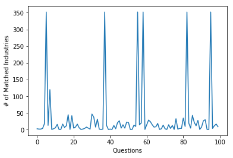

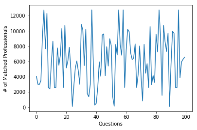

```python
def plot_line(arr_inds, arr_profs):
    fig, ax = plt.subplots()
    plt.plot(range(0,100), arr_inds)
#     ax.set_yticks([0, 10, 15, 100, 150, 200, 300, 350])
    ax.set_xlabel('Questions')
    ax.set_ylabel('# of Matched Industries')

    fig1, ax1 = plt.subplots()
    plt.plot(range(0,100), arr_profs)
#     ax.set_yticks([0, 10, 15, 100, 150, 200, 300, 350])
    ax1.set_xlabel('Questions')
    ax1.set_ylabel('# of Matched Professionals')

plot_line(num_inds, num_profs)
```

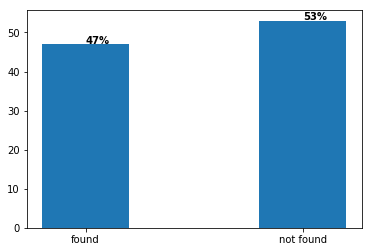

```python
counts = [count_found, count_not_found]
def plot_bar(counts):
    fig, ax = plt.subplots()
    for a,b in zip(['found', 'not found'], counts):
        plt.text(a, b+1, str(b)+"%", color='black', va='center', fontweight='bold')
    plt.bar(['found', 'not found'], counts, 0.4)
plot_bar(counts)
```

# Exp 2

creating keywords based on question tags+title+body and comparing against the combinations of question tags, title and body

```python
from sklearn.feature_extraction.text import CountVectorizer
from sklearn.feature_extraction import stop_words
import re

keywords_series = list()

def industry_prof_queskeywords_map(industry):
    global df_industry_prof_map
    global keywords_series

    item = df_industry_prof_map[df_industry_prof_map['industry']==industry]['prof_ids']
    text_list = list()
    for i in item:
        ques_list = list()
        for prof_id in i:
            # list of questions answered by the prof_id
            questions = list(df_answers[df_answers['answers_author_id']==prof_id]['answers_question_id'])
            ques_list.append(questions)
            # print(ques_list)

            # get the keywords of those questions

            for ques in questions:
                ques_title = df_questions[df_questions['questions_id']==ques]['questions_title']
                ques_body = df_questions[df_questions['questions_id']==ques]['questions_body']

                if len(ques_title) != 0:
                    title = ques_title.iloc[0].lower()
                    # remove special characters and digits
                    title = re.sub("(\\d|\\W_)+", " ", title)
                if len(ques_body) != 0:
                    body = ques_body.iloc[0]
                    body = body.strip(' ')
                    body = re.sub("(\\d|\\W_)+", " ", body)
                text = title + body
                text_list.append(text)

        # creating vocabulary of words
        # eliminating stop words
        keywords = list()
        if len(text_list) != 0:
            cv = CountVectorizer(stop_words=stop_words.ENGLISH_STOP_WORDS)
            cv.fit(text_list)
            keywords = cv.get_feature_names()

        keywords_series.append(keywords)
```

```python
df_industry_prof_map['industry'].apply(industry_prof_queskeywords_map)
```

```
0      None
1      None
2      None
3      None
4      None
5      None
6      None
7      None
8      None
9      None
10     None
11     None
12     None
13     None
14     None
```

[output cut: 47 more lines]

```python
# insert the tags in the original table
df_industry_prof_map['keywords'] = keywords_series
```

```python
df_industry_prof_map.head()
```

|  | industry | prof_ids | tags | keywords |
| --- | --- | --- | --- | --- |
| 0 | not available | [9ced4ce7519049c0944147afb75a8ce3, f718dcf6d2e... | [, businessadministration, honorsociety, admin... | [___, _this, aa, aau, abc, abigail, abilities,... |
| 1 | special events | [68ecc66323b8418092fdd724aaf5be94] | [career-path, hospitality, communication, mark... | [asking, attending, best, business, care, care... |
| 2 | education, tech, media | [c79d4e4fd9af4ab7a7e6b6f433128476] | [nonprofits, connections, entrepreneurship, sk... | [actual, administration, administrator, advice... |
| 3 | renewable energy | [5e9ee8611ee34185a90e4c40f02567ff, 70d367f85f4... | [educational-leadership, aerospace-engineering... | [aeronautic, aeronautics, aerospace, associate... |
| 4 | hospitality & consulting | [1e4cc96c24344c8b806c26c3e6746167] | [capital, job, schools, bakery, business-idea,... | [adopt, advice, angry, appreciated, arts, aver... |

```python
def extract_keywords(question, by):

    title = question['questions_title'].lower()
    title = re.sub("(\\d|\\W_)+", " ", title)
    body = question['questions_body'].lower()
    body = re.sub("(\\d|\\W_)+", " ", body)

    if by == 'title' or by == 'title+tags':
        text = [title]
    elif by == 'body+tags':
        text = [body]
    elif by == 'title+body+tags':
        text = [title + body]

    cv = CountVectorizer(stop_words=stop_words.ENGLISH_STOP_WORDS)
    cv.fit(text)
    keywords = cv.get_feature_names()

    if by == 'title+tags':
        tags = extract_tags(body)
        keywords += tags

    return keywords
```

```python
def predict_by_keywords(by):

    count_found = 0
    count_not_found = 0
    likely_profs = []
    # testing the method on 100 new questions
    for i in range(0, 100):
        print("Question {}".format(i))
        question = df_questions_test.iloc[i]
        question_id = df_questions_test.iloc[i]['questions_id']

        keywords = extract_keywords(question, by)
        likely_profs = predict_professionals(keywords, 'keywords')

        # actual output
        profs = df_answers_test[df_answers_test['answers_question_id']==question_id]
        profs_list = profs['answers_author_id']
        # checking the predicted list contains the professionals who did answer the question
        print(likely_profs[likely_profs['prof_ids'].isin(profs_list)])
        if len(likely_profs[likely_profs['prof_ids'].isin(profs_list)]) == 0:
            count_not_found += 1
        else:
            count_found += 1
        print()
        print()

    return [count_found, count_not_found]
```

```
Question 0
Number of industries matched: 34
Number of professionals matched: 10699
                              prof_ids
6221  ef3371ee80904230a7111c6200ef6b46


Question 1
Number of industries matched: 1
Number of professionals matched: 420
Empty DataFrame
Columns: [prof_ids]
Index: []


Question 2
Number of industries matched: 11
Number of professionals matched: 7390
                              prof_ids
4947  a1006e6a58a0447592e2435caa230f78


Question 3
Number of industries matched: 11
Number of professionals matched: 8049
Empty DataFrame
Columns: [prof_ids]
Index: []


Question 4
Number of industries matched: 57
Number of professionals matched: 11474
                              prof_ids
3194  29b6c4b35d054100ba2bee5ace164bbb
5610  68399ff7b1e5455e976ee8593a9c63f5
6687  b25b37b931f84c588c38d7225ec31dd5
8377  eafd892b820c4ba68d50d924940427db
9640  eefd04d904cb4be7a441ec8bb2af84ba

```

[output cut: 732 more lines]

```
Question 98
Number of industries matched: 16
Number of professionals matched: 7483
Empty DataFrame
Columns: [prof_ids]
Index: []


Question 99
Number of industries matched: 13
Number of professionals matched: 8585
                              prof_ids
3831  9798c8df06244283ba14d30978ec318a
6906  597cd583fb1049deb9b68ce308a992a8
7326  f1ca9370286248aba5aae737f92a07dd
```

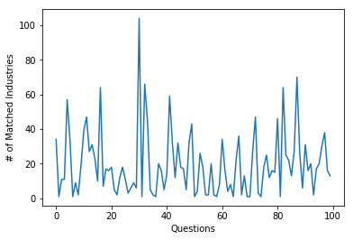

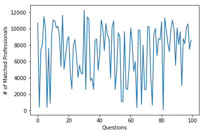

```python
num_profs = list()
num_inds = list()
counts = predict_by_keywords('title')
plot_line(num_inds, num_profs)
```

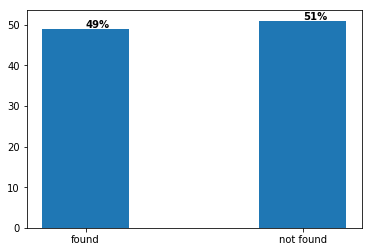

```python
plot_bar(counts)
```

```
Question 0
Number of industries matched: 4
Number of professionals matched: 3798
Empty DataFrame
Columns: [prof_ids]
Index: []


Question 1
Number of industries matched: 1
Number of professionals matched: 2576
Empty DataFrame
Columns: [prof_ids]
Index: []


Question 2
Number of industries matched: 5
Number of professionals matched: 3764
                              prof_ids
2589  a1006e6a58a0447592e2435caa230f78


Question 3
Number of industries matched: 3
Number of professionals matched: 4365
Empty DataFrame
Columns: [prof_ids]
Index: []


Question 4
Number of industries matched: 32
Number of professionals matched: 10329
                              prof_ids
2893  29b6c4b35d054100ba2bee5ace164bbb
5082  68399ff7b1e5455e976ee8593a9c63f5
6056  b25b37b931f84c588c38d7225ec31dd5
7584  eafd892b820c4ba68d50d924940427db
8717  eefd04d904cb4be7a441ec8bb2af84ba
```

[output cut: 730 more lines]

```


Question 98
Number of industries matched: 6
Number of professionals matched: 5592
Empty DataFrame
Columns: [prof_ids]
Index: []


Question 99
Number of industries matched: 1
Number of professionals matched: 2576
                              prof_ids
2054  9798c8df06244283ba14d30978ec318a
```

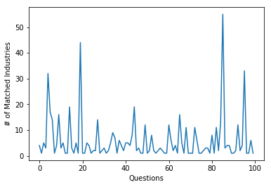

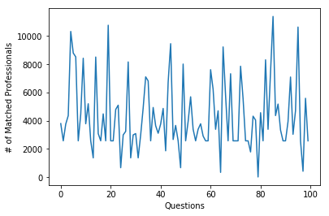

```python
num_profs = list()
num_inds = list()
counts = predict_by_keywords('body+tags')
plot_line(num_inds, num_profs)
```

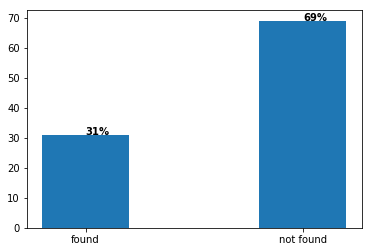

```python
plot_bar(counts)
```

```
Question 0
Number of industries matched: 4
Number of professionals matched: 3798
Empty DataFrame
Columns: [prof_ids]
Index: []


Question 1
Number of industries matched: 1
Number of professionals matched: 2576
Empty DataFrame
Columns: [prof_ids]
Index: []


Question 2
Number of industries matched: 5
Number of professionals matched: 3764
                              prof_ids
2589  a1006e6a58a0447592e2435caa230f78


Question 3
Number of industries matched: 3
Number of professionals matched: 4365
Empty DataFrame
Columns: [prof_ids]
Index: []


Question 4
Number of industries matched: 32
Number of professionals matched: 10329
                              prof_ids
2893  29b6c4b35d054100ba2bee5ace164bbb
5082  68399ff7b1e5455e976ee8593a9c63f5
6056  b25b37b931f84c588c38d7225ec31dd5
7584  eafd892b820c4ba68d50d924940427db
8717  eefd04d904cb4be7a441ec8bb2af84ba
```

[output cut: 729 more lines]

```


Question 98
Number of industries matched: 6
Number of professionals matched: 5592
Empty DataFrame
Columns: [prof_ids]
Index: []


Question 99
Number of industries matched: 1
Number of professionals matched: 2576
                              prof_ids
2054  9798c8df06244283ba14d30978ec318a
```

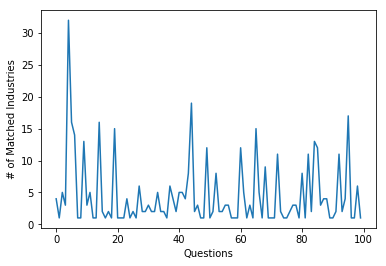

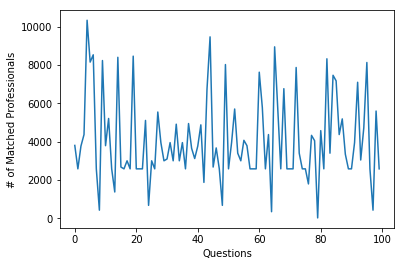

```python
num_profs = list()
num_inds = list()
counts = predict_by_keywords('title+body+tags')
plot_line(num_inds, num_profs)
```

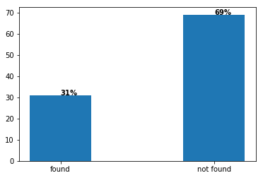

```python
plot_bar(counts)
```

```
Question 0
Number of industries matched: 34
Number of professionals matched: 10699
                              prof_ids
6221  ef3371ee80904230a7111c6200ef6b46


Question 1
Number of industries matched: 2
Number of professionals matched: 2996
Empty DataFrame
Columns: [prof_ids]
Index: []


Question 2
Number of industries matched: 5
Number of professionals matched: 3764
                              prof_ids
2589  a1006e6a58a0447592e2435caa230f78


Question 3
Number of industries matched: 8
Number of professionals matched: 7144
Empty DataFrame
Columns: [prof_ids]
Index: []


Question 4
Number of industries matched: 57
Number of professionals matched: 11474
                              prof_ids
3194  29b6c4b35d054100ba2bee5ace164bbb
5610  68399ff7b1e5455e976ee8593a9c63f5
6687  b25b37b931f84c588c38d7225ec31dd5
8377  eafd892b820c4ba68d50d924940427db
9640  eefd04d904cb4be7a441ec8bb2af84ba

```

[output cut: 734 more lines]

```
Question 98
Number of industries matched: 15
Number of professionals matched: 7436
Empty DataFrame
Columns: [prof_ids]
Index: []


Question 99
Number of industries matched: 7
Number of professionals matched: 6245
                              prof_ids
2808  9798c8df06244283ba14d30978ec318a
5049  597cd583fb1049deb9b68ce308a992a8
5365  f1ca9370286248aba5aae737f92a07dd
```

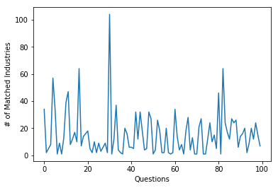

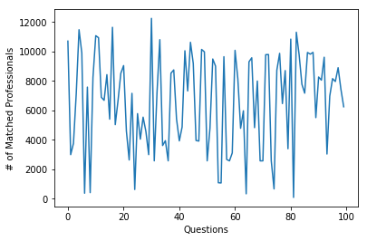

```python
num_profs = list()
num_inds = list()
counts = predict_by_keywords('title+tags')
plot_line(num_inds, num_profs)
```

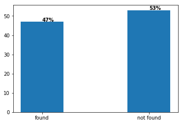

```python
plot_bar(counts)
```

# Exp 3

using the above calculated frequencies to rank the professionals and get a smaller list of resulting professionals list. we'll use the combination of keywords and title as it is giving better accuracy compared to other configurations.

ranking based on answering frequency i.e. the ratio of the cnumber of questions answered to the number of months active of the professionals

```
Text(0,0.5,'Number of Professionals')
```

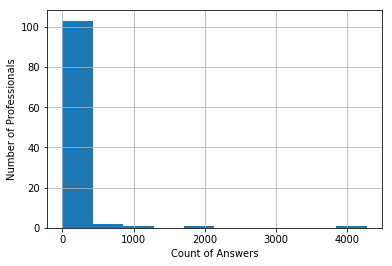

```python
# get all the professionals answering frequencies
prof_ids, counts = np.unique(df_answers['answers_author_id'], return_counts=True)
frequencies = pd.DataFrame(list(zip(prof_ids, counts)), columns=['prof_ids', 'counts'])
ax = frequencies.groupby('counts')['counts'].size().hist()
ax.set_xlabel("Count of Answers")
ax.set_ylabel("Number of Professionals")
```

```
Text(0,0.5,'Number of Professionals')
```

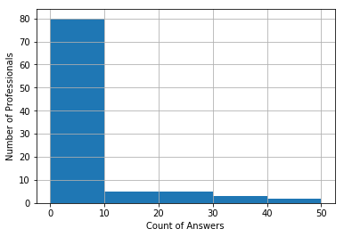

```python
ax = frequencies.groupby('counts')['counts'].size().hist(bins=[0, 10, 20, 30, 40, 50])
ax.set_xlabel("Count of Answers")
ax.set_ylabel("Number of Professionals")
```

```python
prof_id_date = df_professionals[df_professionals['professionals_id'].isin(prof_ids)]['professionals_date_joined']
prof_id_date = pd.to_datetime(prof_id_date)
frequencies['profs_date'] = prof_id_date
frequencies['profs_date'] = frequencies['profs_date'].fillna(pd.to_datetime(0))
```

```python
answerfreq = list()

def get_answerfreq(count, date):
#     print(frequency)
    answerfreq.append(count / ((pd.Timestamp.now()-date) // np.timedelta64(1, 'M')))

frequencies.apply(lambda x: get_answerfreq(x.counts, x.profs_date), axis=1)
```

```
0        None
1        None
2        None
3        None
4        None
5        None
6        None
7        None
8        None
9        None
10       None
11       None
12       None
13       None
14       None
```

[output cut: 47 more lines]

```python
frequencies['ans_freq'] = pd.Series(answerfreq)
frequencies = frequencies.drop('profs_date', axis=1)
frequencies.head()
```

|  | prof_ids | counts | ans_freq |
| --- | --- | --- | --- |
| 0 | 00009a0f9bda43eba47104e9ac62aff5 | 3 | 0.032967 |
| 1 | 000d4635e5da41e3bfd83677ee11dda4 | 3 | 0.005068 |
| 2 | 00271cc10e0245fba4a35e76e669c281 | 24 | 0.263736 |
| 3 | 003cc21be89d4e42bc4424131a378e86 | 4 | 0.044444 |
| 4 | 0046ab8089c04b3a8df3f8c28621a818 | 5 | 0.008446 |

```python
def rank_professionals(df_likely_profs, by):

    # for ranking the professionals first find out the number of questions they have answered before
    df_likely_profs_frequency = pd.merge(frequencies, df_likely_profs, on='prof_ids', how='inner')

    # return the list of likely professionals
    if by == 'ans_freq':
        return df_likely_profs_frequency.sort_values(by, ascending=False).head(400)
    else:
        return df_likely_profs_frequency.sort_values(by)[500:1300]
```

```python
# 0-172, 1-not, 2-172, 3-not, 4-172, 5-172, 6-not, 7-780, 8-not, 9-780,1450, 10-not
count_found = 0
count_not_found = 0
num_profs = list()
num_inds = list()
likely_profs = []
# testing the method on 100 new questions
for i in range(0, 100):
    print("Question {}".format(i))
    question = df_questions_test.iloc[i]
    question_id = df_questions_test.iloc[i]['questions_id']

    keywords = extract_keywords(question, 'title')
    likely_professionals = predict_professionals(keywords, 'keywords')
    likely_profs = rank_professionals(likely_professionals, 'ans_freq')

    # actual output
    profs = df_answers_test[df_answers_test['answers_question_id']==question_id]
    profs_list = profs['answers_author_id']
    # checking the predicted list contains the professionals who did answer the question
    print(likely_profs[likely_profs['prof_ids'].isin(profs_list)])
    if len(likely_profs[likely_profs['prof_ids'].isin(profs_list)]) == 0:
        count_not_found += 1
    else:
        count_found += 1
    print()
    print()
```

```
Question 0
Number of industries matched: 34
Number of professionals matched: 10699
                              prof_ids  counts  ans_freq
3644  ef3371ee80904230a7111c6200ef6b46       4  0.148148


Question 1
Number of industries matched: 1
Number of professionals matched: 420
Empty DataFrame
Columns: [prof_ids, counts, ans_freq]
Index: []


Question 2
Number of industries matched: 11
Number of professionals matched: 7390
                              prof_ids  counts  ans_freq
1752  a1006e6a58a0447592e2435caa230f78     908  1.533784


Question 3
Number of industries matched: 11
Number of professionals matched: 8049
Empty DataFrame
Columns: [prof_ids, counts, ans_freq]
Index: []


Question 4
Number of industries matched: 57
Number of professionals matched: 11474
Empty DataFrame
Columns: [prof_ids, counts, ans_freq]
Index: []


Question 5
Number of industries matched: 34
```

[output cut: 714 more lines]

```


Question 98
Number of industries matched: 16
Number of professionals matched: 7483
Empty DataFrame
Columns: [prof_ids, counts, ans_freq]
Index: []


Question 99
Number of industries matched: 13
Number of professionals matched: 8585
                              prof_ids  counts  ans_freq
2968  f1ca9370286248aba5aae737f92a07dd       4  0.153846
```

[figure not shown]

[figure not shown]

```python
plot_line(num_profs, num_inds)
```

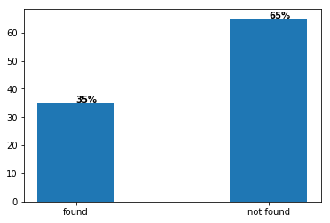

```python
plot_bar([count_found, count_not_found])
```

```python
df_temp = pd.merge(df_answers[['answers_author_id', 'answers_date_added', 'answers_question_id']], df_questions[['questions_id', 'questions_date_added']], left_on='answers_question_id', right_on='questions_id', how='left')
# df_temp.dropna(inplace=True)
df_temp['answers_date_added'] = pd.to_datetime(df_temp['answers_date_added'])
df_temp['questions_date_added'] = pd.to_datetime(df_temp['questions_date_added'])
df_groups = df_temp.groupby('answers_author_id')
```

```python
timefreq = list()

def get_timefreq(prof_id):
#     print(frequency)
    df_data = df_groups.get_group(prof_id)
    time_avg = sum((df_data['answers_date_added'] - df_data['questions_date_added']) // np.timedelta64(1, 'h')) / len(df_data)
    timefreq.append(time_avg)
```

```python
frequencies.apply(lambda x: get_timefreq(x.prof_ids), axis=1)
# get_timefreq('00009a0f9bda43eba47104e9ac62aff5')
```

```
0        None
1        None
2        None
3        None
4        None
5        None
6        None
7        None
8        None
9        None
10       None
11       None
12       None
13       None
14       None
```

[output cut: 47 more lines]

```python
frequencies['time_freq'] = pd.Series(timefreq)
frequencies.tail()
```

|  | prof_ids | counts | ans_freq | time_freq |
| --- | --- | --- | --- | --- |
| 10146 | ffdeaf7003a14c80aa237b35f6f636dc | 1 | 0.001689 | 295.0 |
| 10147 | ffe2f26d5c174e13b565d026e1d8c503 | 6 | 0.240000 | 735.5 |
| 10148 | ffeaf7114b59443581b8acb5a9bfb38a | 1 | 0.001689 | 4466.0 |
| 10149 | fffa0ff907ff4a9a84cb1b142911eee1 | 1 | 0.001689 | 3646.0 |
| 10150 | ffffbe8d854a4a5a8ab1a381224f5b80 | 2 | 0.003378 | 1455.5 |

```python
count_found = 0
count_not_found = 0
likely_profs = []
num_inds = list()
num_profs = list()
# testing the method on 100 new questions
for i in range(0, 100):
    print("Question {}".format(i))
    question = df_questions_test.iloc[i]
    question_id = df_questions_test.iloc[i]['questions_id']

    keywords = extract_keywords(question, 'title')
    likely_professionals = predict_professionals(keywords, 'keywords')
    likely_profs = rank_professionals(likely_professionals, 'time_freq')

    # actual output
    profs = df_answers_test[df_answers_test['answers_question_id']==question_id]
    profs_list = profs['answers_author_id']
    # checking the predicted list contains the professionals who did answer the question
    print(likely_profs[likely_profs['prof_ids'].isin(profs_list)])
    if len(likely_profs[likely_profs['prof_ids'].isin(profs_list)]) == 0:
        count_not_found += 1
    else:
        count_found += 1
    print()
    print()
```

```
Question 0
Number of industries matched: 34
Number of professionals matched: 10699
                              prof_ids  counts  ans_freq  time_freq
3644  ef3371ee80904230a7111c6200ef6b46       4  0.148148     520.75


Question 1
Number of industries matched: 1
Number of professionals matched: 420
Empty DataFrame
Columns: [prof_ids, counts, ans_freq, time_freq]
Index: []


Question 2
Number of industries matched: 11
Number of professionals matched: 7390
                              prof_ids  counts  ans_freq   time_freq
1752  a1006e6a58a0447592e2435caa230f78     908  1.533784  1195.01652


Question 3
Number of industries matched: 11
Number of professionals matched: 8049
Empty DataFrame
Columns: [prof_ids, counts, ans_freq, time_freq]
Index: []


Question 4
Number of industries matched: 57
Number of professionals matched: 11474
Empty DataFrame
Columns: [prof_ids, counts, ans_freq, time_freq]
Index: []


Question 5
Number of industries matched: 34
```

[output cut: 718 more lines]

```

Question 98
Number of industries matched: 16
Number of professionals matched: 7483
Empty DataFrame
Columns: [prof_ids, counts, ans_freq, time_freq]
Index: []


Question 99
Number of industries matched: 13
Number of professionals matched: 8585
                              prof_ids  counts  ans_freq  time_freq
1833  9798c8df06244283ba14d30978ec318a      12  0.020270     179.25
2968  f1ca9370286248aba5aae737f92a07dd       4  0.153846     897.50
```

[figure not shown]

[figure not shown]

```python
plot_line(num_inds, num_profs)
```

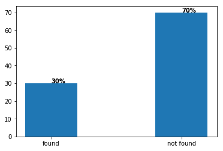

```python
plot_bar([count_found, count_not_found])
```

# Exp 4

```python
df_questions.head()
```

|  | questions_id | questions_author_id | questions_date_added | questions_title | questions_body |
| --- | --- | --- | --- | --- | --- |
| 0 | 332a511f1569444485cf7a7a556a5e54 | 8f6f374ffd834d258ab69d376dd998f5 | 2016-04-26 11:14:26 UTC+0000 | Teacher career question | What is a maths teacher? what is a ma... |
| 1 | eb80205482e4424cad8f16bc25aa2d9c | acccbda28edd4362ab03fb8b6fd2d67b | 2016-05-20 16:48:25 UTC+0000 | I want to become an army officer. What can I d... | I am Priyanka from Bangalore . Now am in 10th ... |
| 2 | 4ec31632938a40b98909416bdd0decff | f2c179a563024ccc927399ce529094b5 | 2017-02-08 19:13:38 UTC+0000 | Will going abroad for your first job increase ... | I'm planning on going abroad for my first job.... |
| 3 | 2f6a9a99d9b24e5baa50d40d0ba50a75 | 2c30ffba444e40eabb4583b55233a5a4 | 2017-09-01 14:05:32 UTC+0000 | To become a specialist in business management... | i hear business management is a hard way to ge... |
| 4 | 5af8880460c141dbb02971a1a8369529 | aa9eb1a2ab184ebbb00dc01ab663428a | 2017-09-01 02:36:54 UTC+0000 | Are there any scholarships out there for stude... | I'm trying to find scholarships for first year... |

```python
question_titles = list(df_questions['questions_title'])
```

```python
from sklearn.feature_extraction.text import TfidfVectorizer
vectorizer = TfidfVectorizer()
vectorizer.fit(question_titles)
sparse_matrix = vectorizer.transform(question_titles)
sparse_matrix.toarray()[0]
```

```
array([0., 0., 0., ..., 0., 0., 0.])
```

```python
from sklearn.decomposition import TruncatedSVD

svd = TruncatedSVD()
eigen_vector = svd.fit_transform(sparse_matrix)

print(len(eigen_vector))
```

```
23831
```

```python
from scipy.spatial.distance import cosine
count_found = 0
count_not_found = 0
def predict_lsa_prof(question):
    global count_found
    global count_not_found
    # test question
    sparse_matrix_test = vectorizer.transform([question['questions_title']])

    eigen_vector_test = svd.transform(sparse_matrix_test)

    eigen_vector_test = [item for sublist in eigen_vector_test for item in sublist]

    distances = list()
    for i in range(0 , len(eigen_vector)):
        distances.append(cosine(eigen_vector[i], eigen_vector_test))

#     q = np.argmin(distances)
    dist_list = np.array(distances).argsort()[:300]
#     print(dist_list)
    print(question_titles[np.argmin(distances)])
    print(question['questions_title'])

    prof_ids = list()
    for i in range(0, len(dist_list)):
        ques_id = df_questions.iloc[dist_list[i]]['questions_id']
    #     print(ques_id)
        prof_id = df_answers[df_answers['answers_question_id']==ques_id]['answers_author_id']
        prof_ids.append(prof_id)

    test_ques_id = question['questions_id']
    #     print(test_ques_id)
    test_prof_id = df_answers_test[df_answers_test['answers_question_id']==test_ques_id]['answers_author_id']
    if len(test_prof_id[test_prof_id.isin(prof_ids)]) == 0:
        count_not_found += 1
    else:
        count_found += 1

#     print(prof_id)
#     print(test_prof_id)

    print()
```

```python
for i in range(0, 10):
    predict_lsa_prof(df_questions_test.iloc[i])
# predict_lsa_prof(df_questions_test.iloc[0])
print(count_found)
print(count_not_found)
```

```
Is there any minors you would suggest getting along with an engineering degree?
When should I begin to look for internships?

What are some good colleges that have good nursing programs?
For those interested in pursuing a career in ecology and evolutionary biology, what types of jobs are available that involve working in the field with real organisms?

Going back to school through community colleges to take classes just for the sake of learning new things?
Is it possible to branch off into speech and hearing therapy from psychology?

I am a graduate and I am working in a production company. So I have no time to join regular courses of Electronic Media.
is it better to specialize your degree or remain general?

For what areas of study are research grants useful?
Which college is the best for computer science?

What classes in college do I need to take to get into aerospace engineering?
How Should I Prepare for an Internship Interview?

What is a typical day in the life of a surgeon?
Travel opportunities for historians

Speech Pathologist vs. Occupational Therapist
Is there a significant difference between going to a public or a private school for undergrad?

How do I stay active during the summer so I am making continuous progress towards bettering my career path?
I am debating on whether to study teaching or psychology. I know that if I put my mind to it I can do which ever one, but how can I come to a conclusion on which major to focus on when I love helping others?

How many years in collage does it take to be an Ophthalmologist?
How long do you need to go to collage for? What profession does it need to be in?

0
10
```